# Introducing Data Science with R - Lab Session

Yu-Yun Chang  
Oct. 20, 2016

## Lab Session Week 6 - Dataframe and Lists

### Before we get started

- install the package **datasets** and **MASS** load it in

```r
require(datasets)
require(MASS)
```

- We would use **sleep** and **phones** in this lab session

## Recap with quick questions

## Question 1

- What are the differences between dataframes and lists?

## Answer 1

```r
# - lists can contain various types of data
# - lists can have variouis lengths of data
```

## Question 2

Explore datasets **sleep** and **phones**.

- Which dataset is a list?

## Answer 2

```r
str(sleep)
```

```
'data.frame':   20 obs. of  3 variables:
 $ extra: num  0.7 -1.6 -0.2 -1.2 -0.1 3.4 3.7 0.8 0 2 ...
 $ group: Factor w/ 2 levels "1","2": 1 1 1 1 1 1 1 1 1 1 ...
 $ ID   : Factor w/ 10 levels "1","2","3","4",..: 1 2 3 4 5 6 7 8 9 10 ...
```

```r
str(phones) #answer
```

```
List of 2
 $ year : num [1:24] 50 51 52 53 54 55 56 57 58 59 ...
 $ calls: num [1:24] 4.4 4.7 4.7 5.9 6.6 7.3 8.1 8.8 10.6 12 ...
```

## Question 3

- Which column within **sleep** data is an ordered factor?

## Answer 3

```r
# None!
str(sleep)
```

```
'data.frame':   20 obs. of  3 variables:
 $ extra: num  0.7 -1.6 -0.2 -1.2 -0.1 3.4 3.7 0.8 0 2 ...
 $ group: Factor w/ 2 levels "1","2": 1 1 1 1 1 1 1 1 1 1 ...
 $ ID   : Factor w/ 10 levels "1","2","3","4",..: 1 2 3 4 5 6 7 8 9 10 ...
```

```r
str(phones)
```

```
List of 2
 $ year : num [1:24] 50 51 52 53 54 55 56 57 58 59 ...
 $ calls: num [1:24] 4.4 4.7 4.7 5.9 6.6 7.3 8.1 8.8 10.6 12 ...
```

## Question 4

- Extract the rows of `group 1` in **sleep**

## Answer 4

```r
sleep[sleep$group==1,]
```

```
   extra group ID
1    0.7     1  1
2   -1.6     1  2
3   -0.2     1  3
4   -1.2     1  4
5   -0.1     1  5
6    3.4     1  6
7    3.7     1  7
8    0.8     1  8
9    0.0     1  9
10   2.0     1 10
```

## Question 5

- Extract the rows that have negative values in `extra` column.

## Answer 5

```r
sleep[sleep$extra < 0, ]
```

```
   extra group ID
2   -1.6     1  2
3   -0.2     1  3
4   -1.2     1  4
5   -0.1     1  5
15  -0.1     2  5
```

## Question 6

- Explore dataset **phones**, and extract the first 6 elements within the column `year`

## Answer 6

```r
head(phones$year)
```

```
[1] 50 51 52 53 54 55
```

## Question 7

- Create a new list **ALL**, which contains both the datasets **sleep** and **phones**

## Answer 7

```r
(ALL <- list(sleep=sleep, phones=phones))
```

```
$sleep
   extra group ID
1    0.7     1  1
2   -1.6     1  2
3   -0.2     1  3
4   -1.2     1  4
5   -0.1     1  5
6    3.4     1  6
7    3.7     1  7
8    0.8     1  8
9    0.0     1  9
10   2.0     1 10
11   1.9     2  1
12   0.8     2  2
13   1.1     2  3
```

[output cut: 17 more lines]

## Exercises

## Before we get started ...

Copy and paste the below information.

```r
movies <- c('Titanic', 'Minions')
like <- c(rep('bad',5), rep('good',2), rep('good', 100))
comments <- c('hate!', 'awful~', 'AWFUL!!','not recommended',
              'the music is not good', 'love the actors',
              rep('soooooo cute!!!!', 20))
```

## Questions

- Create a list, `reviews`. Name the variables within `reviews` as **movies**, **like**, and **comments**
- How many people have sent their comments on the movies?

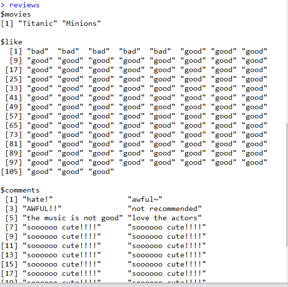

## Questions

A total of 107 people sent their reviews to the two movies. The first 7 elements of **like** are for the movie “Titanic”, and the rest is for “Minions”.

In addition, the first 6 elements of **comments** are given by the first 6 “Titanic” reviewers, and the rest of 20 elements is provided by the last 20 “Minions” reviewers.

- Create a dataframe `review_data`, and convert the list `reviews` into a dataframe (with the information given above).
- Extract the rows with `good` reviews.

## Questions

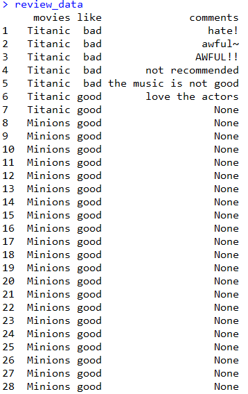

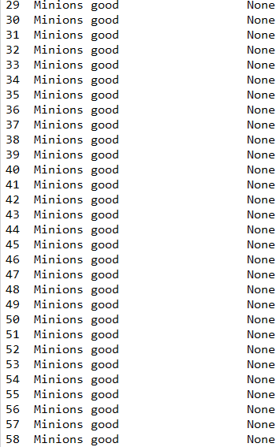

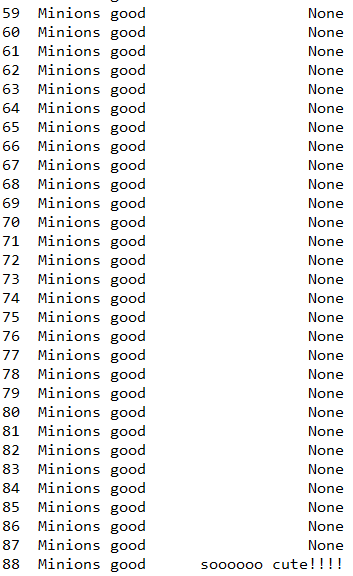

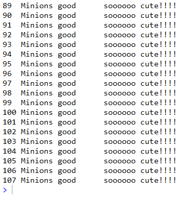

## Answers

```r
reviews <- list(movies=movies, like=like, comments=comments)

length(reviews[[3]])
```

[output not shown]

```r
review_data <- data.frame(
  movies = c(rep('Titanic',7), rep('Minions',100)), like = like,
  comments = c(head(comments), rep('None',81), tail(comments,20)))

review_data[review_data$like=='good',]
```